# Risk Factor Analysis

## Outcome Variable

**Outcome Variable:** pers_wast

## Predictor Variables

**Intervention Variable:** birthwt

**Adjustment Set:**

- arm
- sex
- W_mage
- meducyrs
- feducyrs
- vagbrth
- single
- brthmon
- W_parity
- delta_W_mage
- delta_meducyrs
- delta_feducyrs
- delta_vagbrth
- delta_single
- delta_brthmon
- delta_W_parity

## Stratifying Variables

The analysis was stratified on these variable(s):

- agecat
- studyid
- country

## Data Summary

| agecat | studyid | country | birthwt | pers_wast | n_cell | n |
| --- | --- | --- | --- | --- | --- | --- |
| 0-24 months | CMC-V-BCS-2002 | INDIA | Normal or high birthweight | 0 | 305 | 365 |
| 0-24 months | CMC-V-BCS-2002 | INDIA | Normal or high birthweight | 1 | 17 | 365 |
| 0-24 months | CMC-V-BCS-2002 | INDIA | Low birthweight | 0 | 38 | 365 |
| 0-24 months | CMC-V-BCS-2002 | INDIA | Low birthweight | 1 | 5 | 365 |
| 0-24 months | CMIN | BANGLADESH | Normal or high birthweight | 0 | 8 | 12 |
| 0-24 months | CMIN | BANGLADESH | Normal or high birthweight | 1 | 0 | 12 |
| 0-24 months | CMIN | BANGLADESH | Low birthweight | 0 | 4 | 12 |
| 0-24 months | CMIN | BANGLADESH | Low birthweight | 1 | 0 | 12 |
| 0-24 months | COHORTS | GUATEMALA | Normal or high birthweight | 0 | 706 | 795 |
| 0-24 months | COHORTS | GUATEMALA | Normal or high birthweight | 1 | 17 | 795 |
| 0-24 months | COHORTS | GUATEMALA | Low birthweight | 0 | 69 | 795 |
| 0-24 months | COHORTS | GUATEMALA | Low birthweight | 1 | 3 | 795 |
| 0-24 months | COHORTS | INDIA | Normal or high birthweight | 0 | 3998 | 5268 |
| 0-24 months | COHORTS | INDIA | Normal or high birthweight | 1 | 281 | 5268 |
| 0-24 months | COHORTS | INDIA | Low birthweight | 0 | 763 | 5268 |
| 0-24 months | COHORTS | INDIA | Low birthweight | 1 | 226 | 5268 |
| 0-24 months | COHORTS | PHILIPPINES | Normal or high birthweight | 0 | 2409 | 2768 |
| 0-24 months | COHORTS | PHILIPPINES | Normal or high birthweight | 1 | 106 | 2768 |
| 0-24 months | COHORTS | PHILIPPINES | Low birthweight | 0 | 219 | 2768 |
| 0-24 months | COHORTS | PHILIPPINES | Low birthweight | 1 | 34 | 2768 |
| 0-24 months | CONTENT | PERU | Normal or high birthweight | 0 | 2 | 2 |
| 0-24 months | CONTENT | PERU | Normal or high birthweight | 1 | 0 | 2 |
| 0-24 months | CONTENT | PERU | Low birthweight | 0 | 0 | 2 |
| 0-24 months | CONTENT | PERU | Low birthweight | 1 | 0 | 2 |
| 0-24 months | EE | PAKISTAN | Normal or high birthweight | 0 | 225 | 376 |
| 0-24 months | EE | PAKISTAN | Normal or high birthweight | 1 | 19 | 376 |
| 0-24 months | EE | PAKISTAN | Low birthweight | 0 | 118 | 376 |
| 0-24 months | EE | PAKISTAN | Low birthweight | 1 | 14 | 376 |
| 0-24 months | GMS-Nepal | NEPAL | Normal or high birthweight | 0 | 366 | 596 |
| 0-24 months | GMS-Nepal | NEPAL | Normal or high birthweight | 1 | 39 | 596 |

[output cut: 78 more lines]

The following strata were considered:

- agecat: 0-24 months, studyid: CMC-V-BCS-2002, country: INDIA
- agecat: 0-24 months, studyid: CMIN, country: BANGLADESH
- agecat: 0-24 months, studyid: COHORTS, country: GUATEMALA
- agecat: 0-24 months, studyid: COHORTS, country: INDIA
- agecat: 0-24 months, studyid: COHORTS, country: PHILIPPINES
- agecat: 0-24 months, studyid: CONTENT, country: PERU
- agecat: 0-24 months, studyid: EE, country: PAKISTAN
- agecat: 0-24 months, studyid: GMS-Nepal, country: NEPAL
- agecat: 0-24 months, studyid: IRC, country: INDIA
- agecat: 0-24 months, studyid: JiVitA-3, country: BANGLADESH
- agecat: 0-24 months, studyid: JiVitA-4, country: BANGLADESH
- agecat: 0-24 months, studyid: Keneba, country: GAMBIA
- agecat: 0-24 months, studyid: MAL-ED, country: BANGLADESH
- agecat: 0-24 months, studyid: MAL-ED, country: BRAZIL
- agecat: 0-24 months, studyid: MAL-ED, country: INDIA
- agecat: 0-24 months, studyid: MAL-ED, country: NEPAL
- agecat: 0-24 months, studyid: MAL-ED, country: PERU
- agecat: 0-24 months, studyid: MAL-ED, country: SOUTH AFRICA
- agecat: 0-24 months, studyid: MAL-ED, country: TANZANIA, UNITED REPUBLIC OF
- agecat: 0-24 months, studyid: NIH-Birth, country: BANGLADESH
- agecat: 0-24 months, studyid: NIH-Crypto, country: BANGLADESH
- agecat: 0-24 months, studyid: PROBIT, country: BELARUS
- agecat: 0-24 months, studyid: PROVIDE, country: BANGLADESH
- agecat: 0-24 months, studyid: ResPak, country: PAKISTAN
- agecat: 0-24 months, studyid: SAS-CompFeed, country: INDIA
- agecat: 0-24 months, studyid: TanzaniaChild2, country: TANZANIA, UNITED REPUBLIC OF
- agecat: 0-24 months, studyid: ZVITAMBO, country: ZIMBABWE

### Dropped Strata

Some strata were dropped due to rare outcomes:

- agecat: 0-24 months, studyid: CMIN, country: BANGLADESH
- agecat: 0-24 months, studyid: COHORTS, country: GUATEMALA
- agecat: 0-24 months, studyid: CONTENT, country: PERU
- agecat: 0-24 months, studyid: MAL-ED, country: BANGLADESH
- agecat: 0-24 months, studyid: MAL-ED, country: BRAZIL
- agecat: 0-24 months, studyid: MAL-ED, country: NEPAL
- agecat: 0-24 months, studyid: MAL-ED, country: PERU
- agecat: 0-24 months, studyid: MAL-ED, country: SOUTH AFRICA
- agecat: 0-24 months, studyid: MAL-ED, country: TANZANIA, UNITED REPUBLIC OF
- agecat: 0-24 months, studyid: PROBIT, country: BELARUS
- agecat: 0-24 months, studyid: ResPak, country: PAKISTAN

## Methods Detail

We're interested in the causal parameters $E[Y_a]$ for all values of $a \in \mathcal{A}$. These parameters represent the mean outcome if, possibly contrary to fact, we intervened to set all units to have $A=a$. Under the randomization and positivity assumptions, these are identified by the statistical parameters $\psi_a=E_W[E_{Y|A,W}(Y|A=a,W)]$. In addition, we're interested in the mean of $Y$, $E[Y]$ under no intervention (the observed mean). We will estimate these parameters by using SuperLearner to fit the relevant likelihood factors -- $E_{Y|A,W}(Y|A=a,W)$ and $p(A=a|W)$, and then updating our likelihood fit using a joint TMLE.

For unadjusted analyses ($W=\{\}$), initial likelihoods were estimated using Lrnr_glm to estimate the simple $E(Y|A)$ and Lrnr_mean to estimate $p(A)$. For adjusted analyses, a small library containing Lrnr_glmnet, Lrnr_xgboost, and Lrnr_mean was used.

Having estimated these parameters, we will then use the delta method to estimate relative risks and attributable risks relative to a prespecified baseline level of $A$.

# Results Detail

## Results Plots

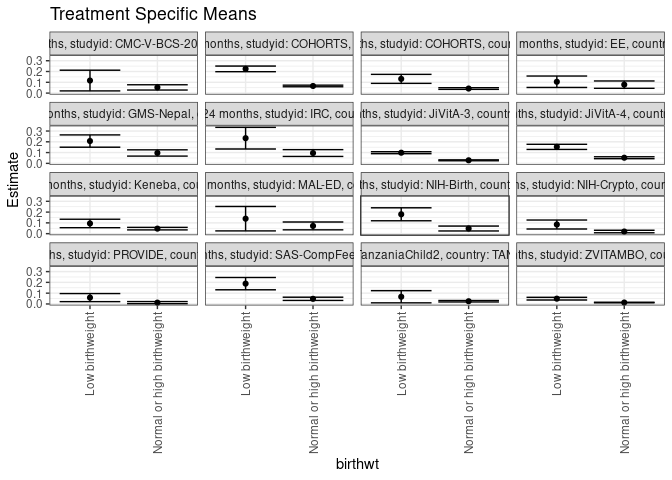

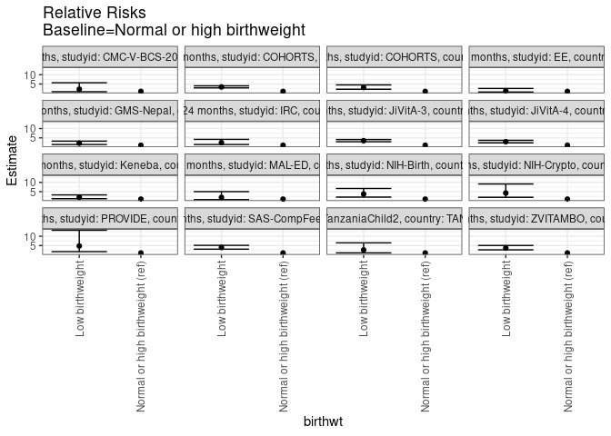

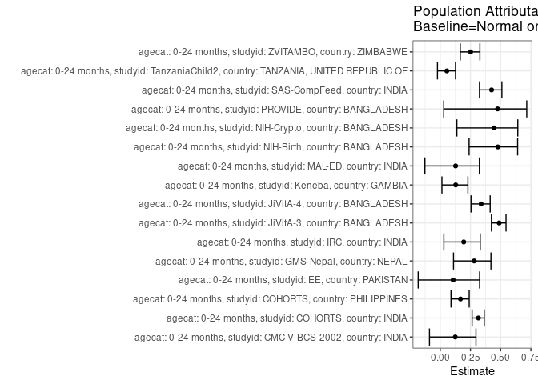

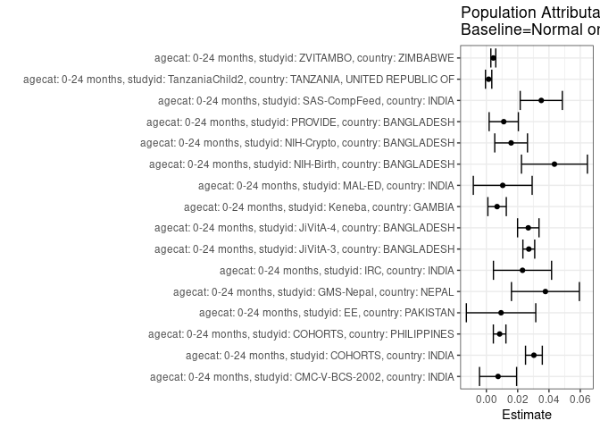

## Results Table

### Parameter: TSM

| agecat | studyid | country | intervention_level | baseline_level | estimate | ci_lower | ci_upper |
| --- | --- | --- | --- | --- | --- | --- | --- |
| 0-24 months | CMC-V-BCS-2002 | INDIA | Normal or high birthweight | NA | 0.0527950 | 0.0283363 | 0.0772538 |
| 0-24 months | CMC-V-BCS-2002 | INDIA | Low birthweight | NA | 0.1162791 | 0.0203350 | 0.2122231 |
| 0-24 months | COHORTS | INDIA | Normal or high birthweight | NA | 0.0658701 | 0.0584430 | 0.0732972 |
| 0-24 months | COHORTS | INDIA | Low birthweight | NA | 0.2244041 | 0.1982388 | 0.2505694 |
| 0-24 months | COHORTS | PHILIPPINES | Normal or high birthweight | NA | 0.0420989 | 0.0342497 | 0.0499481 |
| 0-24 months | COHORTS | PHILIPPINES | Low birthweight | NA | 0.1318031 | 0.0902231 | 0.1733830 |
| 0-24 months | EE | PAKISTAN | Normal or high birthweight | NA | 0.0783773 | 0.0444222 | 0.1123324 |
| 0-24 months | EE | PAKISTAN | Low birthweight | NA | 0.1049796 | 0.0520260 | 0.1579331 |
| 0-24 months | GMS-Nepal | NEPAL | Normal or high birthweight | NA | 0.0965015 | 0.0673765 | 0.1256265 |
| 0-24 months | GMS-Nepal | NEPAL | Low birthweight | NA | 0.2069511 | 0.1499604 | 0.2639419 |
| 0-24 months | IRC | INDIA | Normal or high birthweight | NA | 0.0957208 | 0.0641539 | 0.1272877 |
| 0-24 months | IRC | INDIA | Low birthweight | NA | 0.2335239 | 0.1332922 | 0.3337556 |
| 0-24 months | JiVitA-3 | BANGLADESH | Normal or high birthweight | NA | 0.0285107 | 0.0243085 | 0.0327129 |
| 0-24 months | JiVitA-3 | BANGLADESH | Low birthweight | NA | 0.0988425 | 0.0897656 | 0.1079193 |
| 0-24 months | JiVitA-4 | BANGLADESH | Normal or high birthweight | NA | 0.0523609 | 0.0434421 | 0.0612798 |
| 0-24 months | JiVitA-4 | BANGLADESH | Low birthweight | NA | 0.1531416 | 0.1294107 | 0.1768725 |
| 0-24 months | Keneba | GAMBIA | Normal or high birthweight | NA | 0.0466288 | 0.0350484 | 0.0582091 |
| 0-24 months | Keneba | GAMBIA | Low birthweight | NA | 0.0946275 | 0.0554585 | 0.1337965 |
| 0-24 months | MAL-ED | INDIA | Normal or high birthweight | NA | 0.0717949 | 0.0354836 | 0.1081062 |
| 0-24 months | MAL-ED | INDIA | Low birthweight | NA | 0.1388889 | 0.0256743 | 0.2521034 |
| 0-24 months | NIH-Birth | BANGLADESH | Normal or high birthweight | NA | 0.0477615 | 0.0251786 | 0.0703443 |
| 0-24 months | NIH-Birth | BANGLADESH | Low birthweight | NA | 0.1797425 | 0.1195943 | 0.2398908 |
| 0-24 months | NIH-Crypto | BANGLADESH | Normal or high birthweight | NA | 0.0197988 | 0.0082245 | 0.0313731 |
| 0-24 months | NIH-Crypto | BANGLADESH | Low birthweight | NA | 0.0847787 | 0.0432097 | 0.1263477 |
| 0-24 months | PROVIDE | BANGLADESH | Normal or high birthweight | NA | 0.0122951 | 0.0025102 | 0.0220800 |
| 0-24 months | PROVIDE | BANGLADESH | Low birthweight | NA | 0.0588235 | 0.0215112 | 0.0961359 |
| 0-24 months | SAS-CompFeed | INDIA | Normal or high birthweight | NA | 0.0475142 | 0.0324666 | 0.0625617 |
| 0-24 months | SAS-CompFeed | INDIA | Low birthweight | NA | 0.1883246 | 0.1312427 | 0.2454066 |
| 0-24 months | TanzaniaChild2 | TANZANIA, UNITED REPUBLIC OF | Normal or high birthweight | NA | 0.0251451 | 0.0183956 | 0.0318946 |
| 0-24 months | TanzaniaChild2 | TANZANIA, UNITED REPUBLIC OF | Low birthweight | NA | 0.0666667 | 0.0102001 | 0.1231333 |
| 0-24 months | ZVITAMBO | ZIMBABWE | Normal or high birthweight | NA | 0.0132394 | 0.0107840 | 0.0156949 |
| 0-24 months | ZVITAMBO | ZIMBABWE | Low birthweight | NA | 0.0489469 | 0.0366403 | 0.0612535 |

### Parameter: E(Y)

| agecat | studyid | country | intervention_level | baseline_level | estimate | ci_lower | ci_upper |
| --- | --- | --- | --- | --- | --- | --- | --- |
| 0-24 months | CMC-V-BCS-2002 | INDIA | NA | NA | 0.0602740 | 0.0358249 | 0.0847231 |
| 0-24 months | COHORTS | INDIA | NA | NA | 0.0962415 | 0.0882767 | 0.1042062 |
| 0-24 months | COHORTS | PHILIPPINES | NA | NA | 0.0505780 | 0.0424131 | 0.0587430 |
| 0-24 months | EE | PAKISTAN | NA | NA | 0.0877660 | 0.0591276 | 0.1164044 |
| 0-24 months | GMS-Nepal | NEPAL | NA | NA | 0.1342282 | 0.1068369 | 0.1616195 |
| 0-24 months | IRC | INDIA | NA | NA | 0.1188119 | 0.0872211 | 0.1504026 |
| 0-24 months | JiVitA-3 | BANGLADESH | NA | NA | 0.0556259 | 0.0512873 | 0.0599644 |
| 0-24 months | JiVitA-4 | BANGLADESH | NA | NA | 0.0791432 | 0.0700117 | 0.0882747 |
| 0-24 months | Keneba | GAMBIA | NA | NA | 0.0534759 | 0.0420715 | 0.0648803 |
| 0-24 months | MAL-ED | INDIA | NA | NA | 0.0822511 | 0.0467438 | 0.1177583 |
| 0-24 months | NIH-Birth | BANGLADESH | NA | NA | 0.0912621 | 0.0663660 | 0.1161582 |
| 0-24 months | NIH-Crypto | BANGLADESH | NA | NA | 0.0356164 | 0.0221630 | 0.0490699 |
| 0-24 months | PROVIDE | BANGLADESH | NA | NA | 0.0234009 | 0.0116889 | 0.0351130 |
| 0-24 months | SAS-CompFeed | INDIA | NA | NA | 0.0825959 | 0.0584656 | 0.1067261 |
| 0-24 months | TanzaniaChild2 | TANZANIA, UNITED REPUBLIC OF | NA | NA | 0.0265982 | 0.0197841 | 0.0334124 |
| 0-24 months | ZVITAMBO | ZIMBABWE | NA | NA | 0.0176823 | 0.0150321 | 0.0203326 |

### Parameter: RR

| agecat | studyid | country | intervention_level | baseline_level | estimate | ci_lower | ci_upper |
| --- | --- | --- | --- | --- | --- | --- | --- |
| 0-24 months | CMC-V-BCS-2002 | INDIA | Normal or high birthweight | Normal or high birthweight | 1.000000 | 1.0000000 | 1.000000 |
| 0-24 months | CMC-V-BCS-2002 | INDIA | Low birthweight | Normal or high birthweight | 2.202462 | 0.8549566 | 5.673786 |
| 0-24 months | COHORTS | INDIA | Normal or high birthweight | Normal or high birthweight | 1.000000 | 1.0000000 | 1.000000 |
| 0-24 months | COHORTS | INDIA | Low birthweight | Normal or high birthweight | 3.406768 | 2.8978146 | 4.005110 |
| 0-24 months | COHORTS | PHILIPPINES | Normal or high birthweight | Normal or high birthweight | 1.000000 | 1.0000000 | 1.000000 |
| 0-24 months | COHORTS | PHILIPPINES | Low birthweight | Normal or high birthweight | 3.130795 | 2.1710118 | 4.514889 |
| 0-24 months | EE | PAKISTAN | Normal or high birthweight | Normal or high birthweight | 1.000000 | 1.0000000 | 1.000000 |
| 0-24 months | EE | PAKISTAN | Low birthweight | Normal or high birthweight | 1.339413 | 0.6881483 | 2.607036 |
| 0-24 months | GMS-Nepal | NEPAL | Normal or high birthweight | Normal or high birthweight | 1.000000 | 1.0000000 | 1.000000 |
| 0-24 months | GMS-Nepal | NEPAL | Low birthweight | Normal or high birthweight | 2.144538 | 1.4210813 | 3.236298 |
| 0-24 months | IRC | INDIA | Normal or high birthweight | Normal or high birthweight | 1.000000 | 1.0000000 | 1.000000 |
| 0-24 months | IRC | INDIA | Low birthweight | Normal or high birthweight | 2.439635 | 1.4190739 | 4.194157 |
| 0-24 months | JiVitA-3 | BANGLADESH | Normal or high birthweight | Normal or high birthweight | 1.000000 | 1.0000000 | 1.000000 |
| 0-24 months | JiVitA-3 | BANGLADESH | Low birthweight | Normal or high birthweight | 3.466852 | 2.9246302 | 4.109600 |
| 0-24 months | JiVitA-4 | BANGLADESH | Normal or high birthweight | Normal or high birthweight | 1.000000 | 1.0000000 | 1.000000 |
| 0-24 months | JiVitA-4 | BANGLADESH | Low birthweight | Normal or high birthweight | 2.924729 | 2.3195762 | 3.687760 |
| 0-24 months | Keneba | GAMBIA | Normal or high birthweight | Normal or high birthweight | 1.000000 | 1.0000000 | 1.000000 |
| 0-24 months | Keneba | GAMBIA | Low birthweight | Normal or high birthweight | 2.029380 | 1.2525035 | 3.288123 |
| 0-24 months | MAL-ED | INDIA | Normal or high birthweight | Normal or high birthweight | 1.000000 | 1.0000000 | 1.000000 |
| 0-24 months | MAL-ED | INDIA | Low birthweight | Normal or high birthweight | 1.934524 | 0.7412333 | 5.048859 |
| 0-24 months | NIH-Birth | BANGLADESH | Normal or high birthweight | Normal or high birthweight | 1.000000 | 1.0000000 | 1.000000 |
| 0-24 months | NIH-Birth | BANGLADESH | Low birthweight | Normal or high birthweight | 3.763337 | 2.1033002 | 6.733563 |
| 0-24 months | NIH-Crypto | BANGLADESH | Normal or high birthweight | Normal or high birthweight | 1.000000 | 1.0000000 | 1.000000 |
| 0-24 months | NIH-Crypto | BANGLADESH | Low birthweight | Normal or high birthweight | 4.282010 | 2.0024193 | 9.156728 |
| 0-24 months | PROVIDE | BANGLADESH | Normal or high birthweight | Normal or high birthweight | 1.000000 | 1.0000000 | 1.000000 |
| 0-24 months | PROVIDE | BANGLADESH | Low birthweight | Normal or high birthweight | 4.784314 | 1.7291761 | 13.237320 |
| 0-24 months | SAS-CompFeed | INDIA | Normal or high birthweight | Normal or high birthweight | 1.000000 | 1.0000000 | 1.000000 |
| 0-24 months | SAS-CompFeed | INDIA | Low birthweight | Normal or high birthweight | 3.963545 | 3.0652924 | 5.125022 |
| 0-24 months | TanzaniaChild2 | TANZANIA, UNITED REPUBLIC OF | Normal or high birthweight | Normal or high birthweight | 1.000000 | 1.0000000 | 1.000000 |
| 0-24 months | TanzaniaChild2 | TANZANIA, UNITED REPUBLIC OF | Low birthweight | Normal or high birthweight | 2.651282 | 1.0903832 | 6.446630 |
| 0-24 months | ZVITAMBO | ZIMBABWE | Normal or high birthweight | Normal or high birthweight | 1.000000 | 1.0000000 | 1.000000 |
| 0-24 months | ZVITAMBO | ZIMBABWE | Low birthweight | Normal or high birthweight | 3.697054 | 2.7052091 | 5.052553 |

### Parameter: PAR

| agecat | studyid | country | intervention_level | baseline_level | estimate | ci_lower | ci_upper |
| --- | --- | --- | --- | --- | --- | --- | --- |
| 0-24 months | CMC-V-BCS-2002 | INDIA | Normal or high birthweight | NA | 0.0074789 | -0.0043735 | 0.0193314 |
| 0-24 months | COHORTS | INDIA | Normal or high birthweight | NA | 0.0303714 | 0.0250116 | 0.0357311 |
| 0-24 months | COHORTS | PHILIPPINES | Normal or high birthweight | NA | 0.0084791 | 0.0044615 | 0.0124968 |
| 0-24 months | EE | PAKISTAN | Normal or high birthweight | NA | 0.0093887 | -0.0127869 | 0.0315642 |
| 0-24 months | GMS-Nepal | NEPAL | Normal or high birthweight | NA | 0.0377267 | 0.0160288 | 0.0594245 |
| 0-24 months | IRC | INDIA | Normal or high birthweight | NA | 0.0230911 | 0.0045162 | 0.0416660 |
| 0-24 months | JiVitA-3 | BANGLADESH | Normal or high birthweight | NA | 0.0271152 | 0.0233352 | 0.0308952 |
| 0-24 months | JiVitA-4 | BANGLADESH | Normal or high birthweight | NA | 0.0267822 | 0.0199311 | 0.0336334 |
| 0-24 months | Keneba | GAMBIA | Normal or high birthweight | NA | 0.0068472 | 0.0009621 | 0.0127323 |
| 0-24 months | MAL-ED | INDIA | Normal or high birthweight | NA | 0.0104562 | -0.0083379 | 0.0292503 |
| 0-24 months | NIH-Birth | BANGLADESH | Normal or high birthweight | NA | 0.0435007 | 0.0224374 | 0.0645639 |
| 0-24 months | NIH-Crypto | BANGLADESH | Normal or high birthweight | NA | 0.0158176 | 0.0053583 | 0.0262769 |
| 0-24 months | PROVIDE | BANGLADESH | Normal or high birthweight | NA | 0.0111059 | 0.0017713 | 0.0204404 |
| 0-24 months | SAS-CompFeed | INDIA | Normal or high birthweight | NA | 0.0350817 | 0.0216207 | 0.0485427 |
| 0-24 months | TanzaniaChild2 | TANZANIA, UNITED REPUBLIC OF | Normal or high birthweight | NA | 0.0014532 | -0.0005632 | 0.0034695 |
| 0-24 months | ZVITAMBO | ZIMBABWE | Normal or high birthweight | NA | 0.0044429 | 0.0028651 | 0.0060208 |

### Parameter: PAF

| agecat | studyid | country | intervention_level | baseline_level | estimate | ci_lower | ci_upper |
| --- | --- | --- | --- | --- | --- | --- | --- |
| 0-24 months | CMC-V-BCS-2002 | INDIA | Normal or high birthweight | NA | 0.1240824 | -0.0891428 | 0.2955638 |
| 0-24 months | COHORTS | INDIA | Normal or high birthweight | NA | 0.3155747 | 0.2634579 | 0.3640037 |
| 0-24 months | COHORTS | PHILIPPINES | Normal or high birthweight | NA | 0.1676442 | 0.0889568 | 0.2395353 |
| 0-24 months | EE | PAKISTAN | Normal or high birthweight | NA | 0.1069738 | -0.1824554 | 0.3255594 |
| 0-24 months | GMS-Nepal | NEPAL | Normal or high birthweight | NA | 0.2810638 | 0.1097764 | 0.4193938 |
| 0-24 months | IRC | INDIA | Normal or high birthweight | NA | 0.1943497 | 0.0301162 | 0.3307731 |
| 0-24 months | JiVitA-3 | BANGLADESH | Normal or high birthweight | NA | 0.4874558 | 0.4235336 | 0.5442898 |
| 0-24 months | JiVitA-4 | BANGLADESH | Normal or high birthweight | NA | 0.3384023 | 0.2542504 | 0.4130583 |
| 0-24 months | Keneba | GAMBIA | Normal or high birthweight | NA | 0.1280423 | 0.0139977 | 0.2288961 |
| 0-24 months | MAL-ED | INDIA | Normal or high birthweight | NA | 0.1271255 | -0.1267794 | 0.3238163 |
| 0-24 months | NIH-Birth | BANGLADESH | Normal or high birthweight | NA | 0.4766562 | 0.2385971 | 0.6402840 |
| 0-24 months | NIH-Crypto | BANGLADESH | Normal or high birthweight | NA | 0.4441105 | 0.1375325 | 0.6417104 |
| 0-24 months | PROVIDE | BANGLADESH | Normal or high birthweight | NA | 0.4745902 | 0.0290084 | 0.7156973 |
| 0-24 months | SAS-CompFeed | INDIA | Normal or high birthweight | NA | 0.4247390 | 0.3246016 | 0.5100296 |
| 0-24 months | TanzaniaChild2 | TANZANIA, UNITED REPUBLIC OF | Normal or high birthweight | NA | 0.0546337 | -0.0229578 | 0.1263399 |
| 0-24 months | ZVITAMBO | ZIMBABWE | Normal or high birthweight | NA | 0.2512625 | 0.1655810 | 0.3281458 |